# Delaunay Neighborhood Final Closure Review

Frozen project-specific analysis and BANKSY read-only handoff

发布于

2026年10月26日

## 审阅状态

**DELAUNAY_ANALYSIS_CLOSURE_READY**

本报告是已批准科学分析的时间戳审阅版本。它冻结当前PN标签、Connected Regions以及Interior/Boundary/Surroundings结果，仅适用于本项目。它不是后续全部空间分析的默认流程，也不自动应用于BANKSY。本次没有重新选择K、重新聚类、执行Spatial Co-occurrence或新批次校正。

## 主要结论

# Delaunay Spatial Neighborhood 最终收尾结论

## 最终状态

**DELAUNAY_ANALYSIS_CLOSURE_READY**

冻结Delaunay图、统一PN1–PN8标签、技术标志和既有K选择结果均未改变。本轮没有运行RCTD、NMF、K-means、edgeR、GSEA、LR、空间共现或新批次校正。

## 完成度

- 126,449个QC Bin50全部纳入版本审计；125,471个具有统一PN标签并进入连通区域分析。
- 冻结图包含357,959条无向边，按patient、ROI和tissue component限制，最大边长35.36 μm。
- 共保留29,750个connected regions：Singleton 13,148，2–4 Bin50 9,655，5–9 Bin50 4,665，≥10 Bin50 2,282。
- 505/2,282个≥10 Bin50区域具有全部预设zone；其余保留为PARTIAL_ZONE_COVERAGE。
- ssDNA配准仅对9/21位患者有已审核映射。本轮实际生成9个代表区域overlay；其余患者仅使用真实Bin50坐标，不伪造组织学配准。

## 可保留的PN组成描述

Reference18为混合Bin50的连续权重。以下为按区域Bin数加权的主要组成，不是单细胞计数，也不是独立病理验证：

- PN1: AT1 (0.192), B (0.191), Lymphatic endothelial (0.131), Ciliated epithelial (0.112)
- PN2: AT1 (0.216), B (0.148), Lymphatic endothelial (0.116), Fibroblast (0.094)
- PN3: AT1 (0.197), B (0.173), Fibroblast (0.144), Lymphatic endothelial (0.139)
- PN4: AT1 (0.223), B (0.130), Lymphatic endothelial (0.120), Fibroblast (0.092)
- PN5: AT1 (0.210), B (0.159), Lymphatic endothelial (0.119), Fibroblast (0.106)
- PN6: B (0.146), AT1 (0.144), Lymphatic endothelial (0.128), Fibroblast (0.084)
- PN7: AT1 (0.230), B (0.157), Blood endothelial (0.112), Fibroblast (0.086)
- PN8: AT1 (0.208), Lymphatic endothelial (0.153), B (0.136), Perivascular/mesothelial stromal (0.082)

全部PN在3张芯片均出现。具有≥10 Bin50区域的患者覆盖为：PN1 21/21; PN2 20/21; PN3 21/21; PN4 20/21; PN5 18/21; PN6 20/21; PN7 18/21; PN8 21/21。PN标签仍应保持中性命名。

## Local region与周围组成

区域严格由同一patient、ROI、tissue component、PN及真实Delaunay边定义。面积为Bin50数×625 μm²，不填补空洞。以下模式通过患者内region中位数后再跨患者汇总，属于描述性证据：

- PN2 | INTERIOR_MINUS_INNER_BOUNDARY | Inflammatory monocyte/macrophage: median patient-level difference=+0.117, direction consistency=100%, n=17 patients.
- PN6 | REGION_MINUS_RING_0_50 | AT1: median patient-level difference=-0.092, direction consistency=100%, n=20 patients.
- PN7 | REGION_MINUS_RING_0_50 | Lymphatic endothelial: median patient-level difference=-0.089, direction consistency=100%, n=18 patients.
- PN6 | REGION_MINUS_COMPONENT_BACKGROUND | AT1: median patient-level difference=-0.073, direction consistency=100%, n=20 patients.
- PN7 | REGION_MINUS_COMPONENT_BACKGROUND | Lymphatic endothelial: median patient-level difference=-0.065, direction consistency=100%, n=18 patients.
- PN7 | REGION_MINUS_RING_50_100 | Lymphatic endothelial: median patient-level difference=-0.065, direction consistency=100%, n=18 patients.
- PN6 | REGION_MINUS_RING_50_100 | AT1: median patient-level difference=-0.064, direction consistency=100%, n=20 patients.
- PN6 | INTERIOR_MINUS_INNER_BOUNDARY | AT1: median patient-level difference=-0.052, direction consistency=93%, n=15 patients.
- PN7 | REGION_MINUS_RING_0_50 | Blood endothelial: median patient-level difference=+0.050, direction consistency=100%, n=18 patients.
- PN4 | INTERIOR_MINUS_INNER_BOUNDARY | Alveolar/resident macrophage: median patient-level difference=+0.049, direction consistency=100%, n=15 patients.
- PN1 | REGION_MINUS_RING_0_50 | Ciliated epithelial: median patient-level difference=+0.043, direction consistency=100%, n=21 patients.
- PN8 | REGION_MINUS_RING_0_50 | Fibroblast: median patient-level difference=-0.043, direction consistency=100%, n=21 patients.

大型区域的外环高度重叠：99.7%的区域至少一个环带与其他区域环带共享Bin。因此region-level环带不能作为独立生物学重复；本报告不对环带做伪重复显著性检验。

## ssDNA、芯片与疾病解释

- 9位已有坐标审计的患者可以在ssDNA上定位connected regions。图中保持25×25 μm tile，不做平滑。
- 其余12位没有可靠ssDNA映射，因此不能声称完成21例组织学验证。
- 既有特征空间审计显示：疾病调整后chip partial R²约0.598；进一步调整UMI、nGenes和graph degree后仍约0.408。该差异可能同时包含技术批次、取材和患者组成异质性。
- 患者级、chip调整的探索性疾病比较共有96个预设contrast；FDR<0.05为0。因此本轮没有可正式宣称的疾病相关PN/region差异。

## 与冻结NMF K=7的关系

按dominant label比较，ARI为J2=0.018, K8=0.052, L3=0.011，NMI为J2=0.037, K8=0.036, L3=0.025。两种方法使用同一Reference18来源，低一致性说明分辨率与目标不同，不构成独立验证。Delaunay增加的是同标签真实邻接region及其局部边界/周围描述；NMF保留连续factor usage。

## 论文可用范围

- 可正式保留：图构建/QC、固定标签的可复现映射、全部connected-component清单、区域大小/碎片化、患者级覆盖、9例已验证ssDNA定位。
- 可作为空间描述：PN组成、≥10 Bin50区域、内部/边界/周围组成及Delaunay-NMF对应。
- 仅探索性：跨疾病比较、跨芯片PN比例、特定生物学niche命名、外环差异。
- 不支持：把所有component称为aggregate、把PN称为独立病理niche、把环带当独立重复、宣称21例均完成组织学验证。

## 收尾判断

Delaunay路线的预定收尾工作已完成，没有必须通过再次选K或重新聚类解决的缺口。剩余问题是独立组织学验证、未配准的12例ssDNA、批次/组成解耦及更稳健的空间表征，适合作为BANKSY阶段的明确交接问题。本任务到此停止，不自动启动BANKSY。

## 方法与局限性

# 方法与局限

## 冻结输入

- G15/UMI50 Bin50，21位患者，Reference18连续RCTD权重。
- 每位patient、ROI、tissue component独立构建distance-limited Delaunay图；最大边长35.36 μm。
- 使用既有统一PN1–PN8、classification confidence、OOD_UNASSIGNED和NOT_EVALUABLE。没有重新聚类或选K。

## Connected region定义

同一PN Bin50仅在存在真实Delaunay边时连通。全部29,750个component均保留。Singleton、2–4、5–9和≥10 Bin50分别报告；“connected region”不等于“aggregate”。面积定义为Bin50数×625 μm²，组织空洞不填补。

## Interior、boundary与surrounding

- Inner boundary：region内部且至少有一个图邻居位于region外。
- Interior：region中非inner-boundary的Bin50。
- Immediate outside：通过一条Delaunay边直接连接到region的外部Bin50。
- 0–50 μm与50–100 μm ring：从region boundary tile边缘计算最近近似欧氏距离；immediate outside从0–50 μm ring中排除。
- 所有zone限制在同一patient、ROI和tissue component；不同focal region的ring允许重叠但明确标记。
- ≥5 Bin50区域计算region/interior/boundary；≥10 Bin50区域再计算surrounding。zone少于3 Bin（background少于10 Bin）标记NOT_EVALUABLE。

## 汇总与统计单位

组成差异先在每个region计算，再在患者内取region中位数，最后跨患者描述。没有把Bin50或重叠ring作为独立患者。疾病比较仅使用患者级指标，并以chip作为协变量；BH-FDR覆盖预设全部比较。

## 组织学与NMF

仅对既有审计通过的9位患者复用芯片特异仿射变换。每个tile保持25×25 μm。不对其余12位构造伪配准。冻结NMF K=7仅加载既有usage进行描述性对照，没有重新拟合。

## 关键局限

1. PN与marker、NMF均源于同一RNA/Reference18体系，不能作为独立生物学验证。
2. chip-associated variation较强，统一PN的跨芯片可比性仅适合带chip信息的描述。
3. 99.7%的大型区域存在ring重叠，区域周围结果高度相关。
4. 只有9/21位患者具有可复用的已验证ssDNA配准。
5. 连通性受固定图和离散PN标签影响；碎片化不应通过事后平滑隐藏。
6. 本轮未做新的空间共现、LR、edgeR、GSEA、批次校正或疾病发现分析。

## BANKSY交接说明

# BANKSY交接说明

## 可直接继承的对象

- 冻结Reference18连续权重和126,449个QC Bin50。
- patient、chip、disease、ROI、tissue component、真实坐标及UMI/nGenes。
- 357,959条经审核Delaunay边及degree/boundary QC。
- 统一PN1–PN8、confidence、OOD/NOT_EVALUABLE标志。
- 全部29,750个connected regions及固定的area/fragmentation定义。
- 9位患者经审核的ssDNA仿射配准。

## BANKSY应优先回答的问题

1. 在不依赖当前PN硬标签的情况下，空间平滑表征是否能减少碎片化且保留真实边界？
2. chip variation在空间表征中是否仍占主导？必须按患者留出与chip敏感性报告，不能用训练内稳定性代替验证。
3. BANKSY识别的区域是否与Delaunay ≥10 Bin50 regions在位置、组成和尺度上对应？
4. 当前仅505个大型region具备全部zone，BANKSY是否能定义更稳健、非重叠或层级化的boundary/surrounding结构？
5. 9例ssDNA支持的形态位置能否复现；其余12例必须先获得可靠配准才能做组织学结论。

## 建议的比较基线

- 以patient为评估单位；保持相同QC、Reference18、物理坐标和组织边界。
- 与Delaunay比较：患者覆盖、composition separation、同标签邻接、singleton/2–4比例、≥10区域Bin比例、UMI/nGenes/degree敏感性和chip依赖。
- 保留原始BANKSY标签，不根据疾病P值或预期免疫故事选参数。
- 不要求BANKSY复现PN1–PN8编号；使用组成与空间特征建立对应，并允许无可靠对应。

## 启动门槛

本次Delaunay收尾状态为 **DELAUNAY_ANALYSIS_CLOSURE_READY**。这表示Delaunay结果、限制和比较基线已整理完毕，并不表示BANKSY已获自动授权启动。本任务结束后停止。

## BANKSY输入只读审核

# BANKSY输入交接只读审核

状态：**PASS — READY_NOT_RUN**。本次仅审核并冻结输入指针，没有初始化或运行BANKSY。

## 可交接输入

- 原始计数：`results\reanalysis\bin50_input\BIN50_joint_reanalysis_tissue_raw_counts_common_genes.h5ad`，形状 `178,044 × 27,618`，稀疏矩阵类型 `_CSRDataset`，dtype `uint32`。
- 正式Bin50：必须使用冻结Reference18输入中的精确Bin ID，共 **126,449** 个；全部可在raw counts中一对一定位。患者、芯片、疾病及坐标完全一致。
- 坐标：正式分析坐标为 `x_um=x_raw/2`、`y_um=y_raw/2`；Bin50物理尺寸为25 × 25 μm。
- 临床信息：21位患者，K8/J2/L3各7位；SSc-ILD 9、IPF 6、HC 6。
- 基因注释：27,618个Ensembl ID按raw矩阵列顺序完全匹配；全部有symbol映射，无mapping conflict；有20行涉及重复symbol，后续不得直接按symbol静默合并。
- ssDNA：9/21位患者有已验证全局几何配准；其余12位标记 `SSDNA_NOT_AVAILABLE`。

## 关键门控

仅按 `nGenes≥15、UMI≥50` 从raw H5AD重新筛选会得到 **133,026** 个Bin，比正式冻结集合多 **6,577** 个。因此BANKSY必须读取 `16_BANKSY_FORMAL_BIN_INDEX.tsv.gz` 的精确ID，不允许以阈值筛选替代。

冻结Reference18表中的 `nUMI/nGene` 与当前common-gene raw H5AD派生的QC字段来自不同计数口径，不能相互覆盖；交接索引同时保留两套字段并明确其来源。

## 结论

输入在文件、ID、顺序、坐标及患者元数据层面已通过交接审核。ssDNA不是BANKSY建模的必需输入，只能在9位已验证患者中用于后续组织学审阅。BANKSY尚未运行。

## BANKSY分析方案（未执行）

# BANKSY分析方案（交接草案，未执行）

## 分析边界

BANKSY应作为独立空间表示学习路线启动，不继承Delaunay PN1–PN8为默认标签，也不以复现PN、NMF或免疫故事为优化目标。冻结Delaunay结果仅作为描述性对照。

## 冻结输入

1. 用 `16_BANKSY_FORMAL_BIN_INDEX.tsv.gz` 精确选取126,449个正式Bin50。
2. 从审计通过的raw-count H5AD按 `raw_h5ad_obs_index` 和冻结ID读取计数，不重新定义QC。
3. 使用27,618行顺序一致的Ensembl注释；重复gene symbol须显式处理并留痕。
4. 保留patient、chip、disease、ROI、tissue component、x/y坐标和QC字段。

## 建议的正式执行门控

- 先在每张芯片选择一位代表患者做计算规模、稀疏矩阵、坐标和输出checkpoint验证。
- 预先固定BANKSY参数网格、随机种子、邻域定义及K选择标准；不得根据疾病P值或预期免疫类别选参。
- 患者内建图，禁止跨patient/ROI/tissue component连接。
- 明确区分训练内稳定性、patient-held-out稳定性和组织学验证。
- 保留chip-aware解释；不得自动运行Harmony、CCA、RPCA或把Delaunay患者内中心化规则移植到BANKSY。
- 只有9位患者可进行现有ssDNA overlay审核；其余12位不得伪造配准。

## 尚未授权

本文件不是执行指令。不得启动BANKSY、重新聚类、疾病比较、LR、TCR/BCR或新的批次校正，直至收到下一条正式指令。

## Figure atlas

### Figure 1. Spatial Graph and Input QC

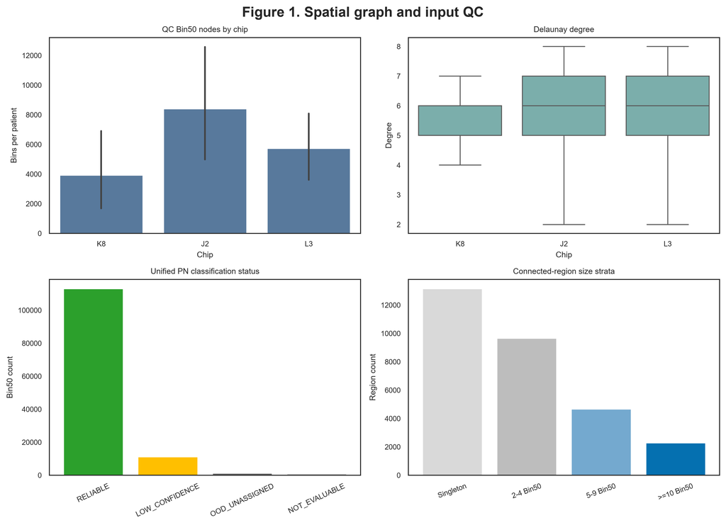

### Figure 2. Neighborhood Composition and Marker Concordance

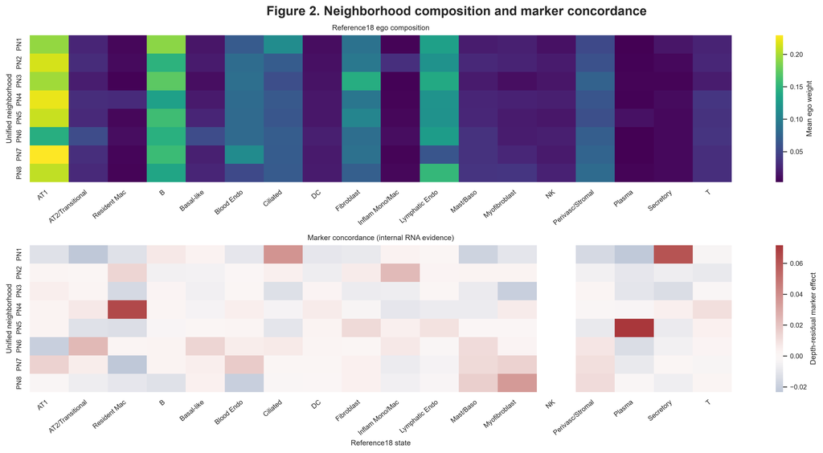

### Figure 3. Spatial Neighborhood Maps Across Patients

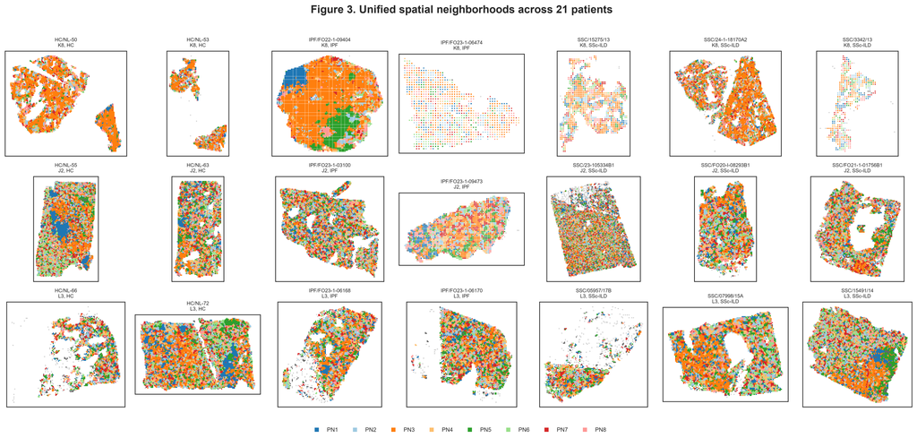

### Figure 4. Local Connected Region Size and Fragmentation

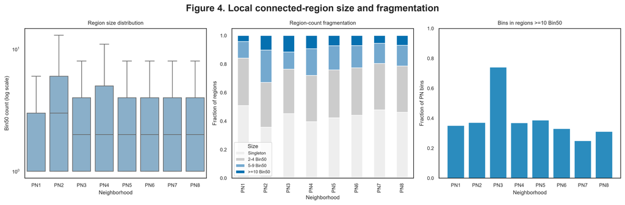

### Figure 5. Connected Regions Overlaid on ssDNA

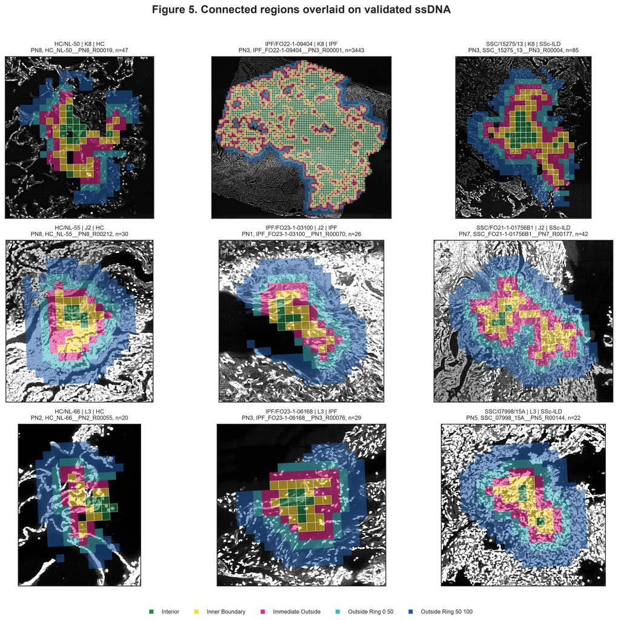

### Figure 6. Region Interior, Boundary and Surrounding Composition

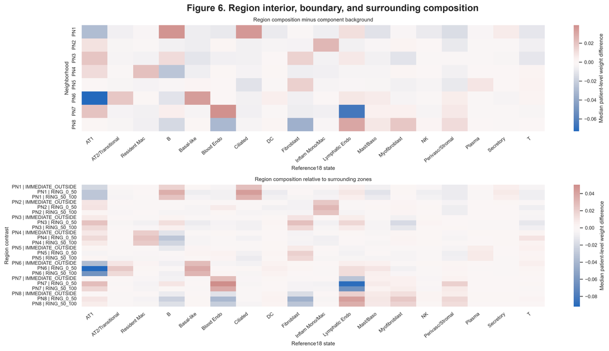

### Figure 7. Delaunay and Frozen NMF K7 Comparison

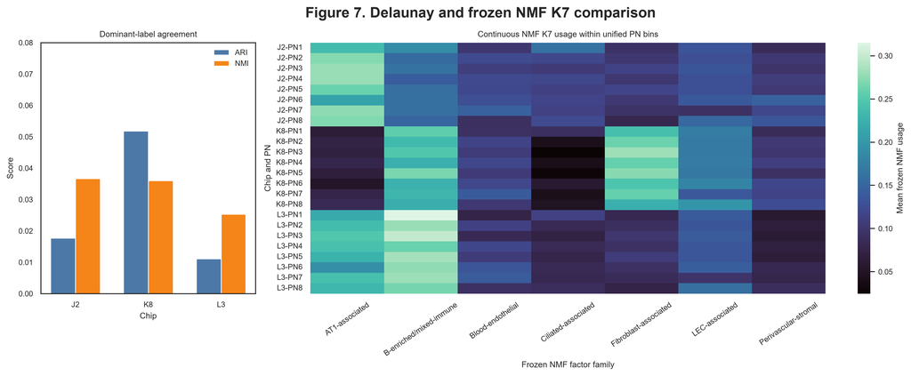

### Figure 8. Chip-aware Patient-level Summary

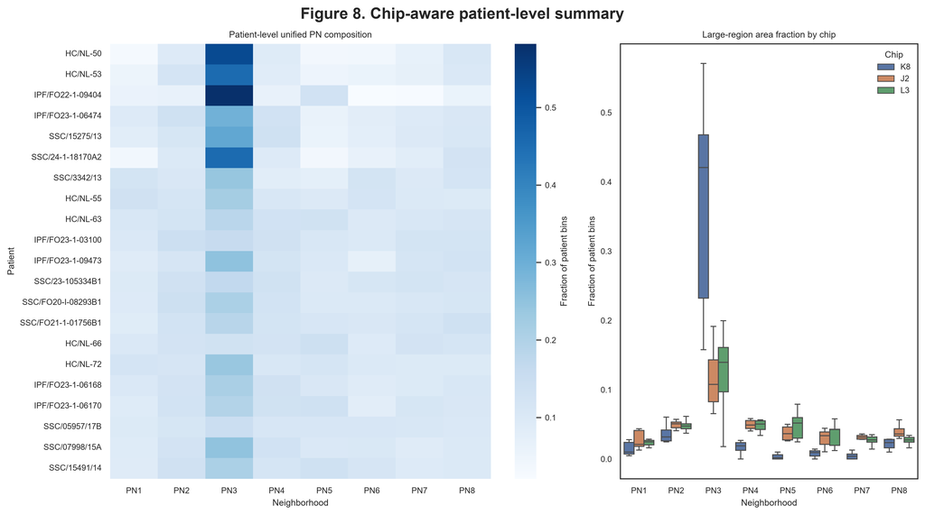

## Reproducibility

正式执行脚本、输入哈希、参数及输出哈希均保存在本收尾目录。BANKSY输入仅完成只读交接审核，状态为 `READY_NOT_RUN`。